# Empirical Exercise 1 Family Firms

MG205 Econometrics Theory and Applications

José Ignacio González Rojas

j.i.gonzalez-rojas@lse.ac.uk

London School of Economics and Political Science

September 30, 2024

## Plan for today

- Who am I?
- Let’s meet the team
- I propose we work like this
- Time for feedback, further clarifications, and other questions
- We’ll review Mathematics and Statistics applying them to Family Firms

## Who am I?

- José Ignacio González Rojas.
- My name is pronounced Ho-SEH Ig-NAW-see-oh.
- I am from Costa Rica. 🇨🇷 (Central America)
- I am MRes Candidate in Economics and Management.
- I study how to make supply chains more resilient to globalisation.

## Let’s meet the team

### Introduce me to the person sitting next to you

1. How would you like us to call you?
2. How do you feel about quantitative methods?
3. Can you tell us an unexpected/fun fact? Or what would you like us to know about you?
4. Do you have any experience with programming languages? Python, R, STATA, Julia, SAS, SPSS, MatLab?

## I propose we work like this

### Classes

#### Types

- Topics: Recap of the theory and work on selected exercises.
- Empirical Exercises: Apply a topic to analyse a research question. Use data and code from replication packages of published articles.
- Formative Assessment: A quiz to test your understanding of the topics at the end of each term.

## I propose we work like this

### Classes

#### Prepare for the class

- Topics: Attempt the exercises before the class. I’ll classify them as easy, medium, and hard.
- Empirical Exercises: Read the Introduction, Conclusion, and the section related to the empirical exercise. Run the STATA code, and query the help command in you don’t understand something. Answer the questions with complete sentences.
- Formative Assessment: Review consistently through the term.

## I propose we work like this

### Classes

#### Outside the class

- Class exercises:
  - Work together. I suggest pairs.
  - Cross-check your answers.
  - Explain an exercise to your partner, on a whiteboard. Verbalise your thoughts.
- Past papers:
  - Solve past papers as if you had no time constraint.
  - Summarise the gist of each question.
  - Solve them again in a concise way.
  - Present the exercises to your classmates. Groups of 3-5 students work best.

## Time for feedback, further clarifications, and other questions

- **Time:** Thursday 15:00-16:00.
- **Location:** The Marshall Building 4.19
- 15 minute slots.
- Book via Student Hub.
- Weeks AT 1, AT 7, WT 1, and another week there won’t be office hours.
- In exchange, I offer you office hours in Summer Term.

# Family firms

## Motivation

### Mexico

- 90% of firms are family firms. (INEGI, 2021)
- 10-15% of their CEOs are family members, regardless of the firm’s size. (INEGI, 2021)

### USA

Far from mom-and-pop stores, family firms are large and complex. (Pérez-González, 2006)

## Question

### Who should be a CEO of a family firm?

- Externally appointed CEO
  - In favour:
  - Against:
- Family member
  - In favour:
  - Against:

## Question

### Who should be a CEO of a family firm?

#### Focus

- Shareholders.
- Society’s impact through producitivity.

## Theoretical predictions

### Choose a family member

1. Direct knowledge transfer from previous CEO to incoming family-member CEO.
2. Culture of the company, and know-how about industry.
3. Family is part of firm’s identity, hence, the employees could retain the attachment to the company.
4. Family member is emotionally invested in the firm.

## Theoretical predictions

### Choose an external candidate

1. External candidate could be more talented. (Larger pool implies higher competition)
2. Career incentives and prove their worth earlier.
3. Lack of attachment makes tough decisions easier to take.

## Data

- Data set: COMPUSTAT
- Object of study: Non-financial and non-utility firms in 1994.
- Sample restrictions:
  - Found prior to 1987.
  - Transition ocurred between 1980 and 2001.
  - **Sample size:** 335 firms.
- Pedigree of CEO? Incoming CEO attended a US selective college.

## Measurement of CEO’s performance

### Abnormal returns

$$\begin{align}
\text{Abnormal return}_{it+2} &= \underbrace{\frac{\text{Share price}_{it+2}-\text{Share price}_{it}}{\text{Share price}_{it}}}_{\text{Firm return}} \\
&- \underbrace{\frac{\text{Market index}_{it+2}-\text{Market index}_{it}}{\text{Market index}_{it}}}_{\text{Market return}}
\end{align}$$

## Measurement of CEO’s performance

### Income-to-assets ratio

Operating income of a firm.

$$\begin{align}
\Delta\text{Profits}_{it} &= \frac{\text{ItA Ratio}_{it+1}+\text{ItA Ratio}_{it+2}+\text{ItA Ratio}_{it+3}}{3} \\
&-\frac{\text{ItA Ratio}_{it-1}+\text{ItA Ratio}_{it-2}+\text{ItA Ratio}_{it-3}}{3}
\end{align}$$
$\Delta\text{Profits}_{it}$ is the (average over three years) return on assets following the incoming CEO joining firm $i$ minus the (average over three years) return on assets prior to the incoming CEO joining firm $i$.

## Hypotheses

- Nepotism leads to lower firm performance.
- Family transitions to lead to worse performance (relative to unrelated transitions) especially when the family candidate did not attend a selective college.

## Analysis

### Load the data

````markdown
```{stata}
use "../data/family_firms.dta", clear
```
````

```
Running /Applications/Stata/sysprofile.do ...
```

## Analysis

### Q1: # of observations. Family vs. unrelated transitions. Share of family transitions.

````markdown
```{stata}
count

tabulate family
```
````

```
  335

 dummy=1 if |
 new CEO is |
 related to |
   founder, |
      large |
shareholder |
         or |
 preceeding |
        CEO |      Freq.     Percent        Cum.
------------+-----------------------------------
          0 |        213       63.58       63.58
          1 |        122       36.42      100.00
------------+-----------------------------------
      Total |        335      100.00
```

## Analysis

### Q2: Rename. Family transitions in 1998. Share of family transitions in 1997.

````markdown
```{stata}
* Rename
rename yrin transition_year

* Family transitions in 1998
tabulate transition_year family

* Share of family transitions in 1997
summarize family if transition_year == 1997
```
````

```
           | dummy=1 if new CEO is
      year |  related to founder,
  incoming | large shareholder or
CEO became |    preceeding CEO
       ceo |         0          1 |     Total
-----------+----------------------+----------
      1981 |         2          2 |         4
      1982 |         2          2 |         4
      1983 |         3          5 |         8
      1984 |         1          6 |         7
      1985 |         3          3 |         6
      1986 |         5          9 |        14
      1987 |         5          6 |        11
      1988 |         5          5 |        10
      1989 |         9          6 |        15
      1990 |        23          9 |        32
      1991 |        19         10 |        29
      1992 |        15          5 |        20
      1993 |        18          6 |        24
      1994 |        19         10 |        29
      1995 |        26          9 |        35
      1996 |        13          7 |        20
      1997 |        16         12 |        28
      1998 |         9          6 |        15
      1999 |        16          4 |        20
      2000 |         4          0 |         4
-----------+----------------------+----------
     Total |       213        122 |       335

    Variable |        Obs        Mean    Std. dev.       Min        Max
-------------+---------------------------------------------------------
      family |         28    .4285714    .5039526          0          1
```

## Analysis

### Q3: Descriptive statistics of the age of the CEO appointed

````markdown
```{stata}
* Descriptive statistics of the age of the CEO appointed
summarize age

* Monthly analysis
generate age_months = 12 * age
summarize age_months
```
````

```
    Variable |        Obs        Mean    Std. dev.       Min        Max
-------------+---------------------------------------------------------
         age |        335    47.86269    7.439916         27         74

    Variable |        Obs        Mean    Std. dev.       Min        Max
-------------+---------------------------------------------------------
  age_months |        335    574.3522    89.27899        324        888
```

## Analysis

### Q4: Who appoints younger CEOs?

````markdown
```{stata}
scatter age transition_year, title(Are younger CEOs are being appointed over time?)
```
````

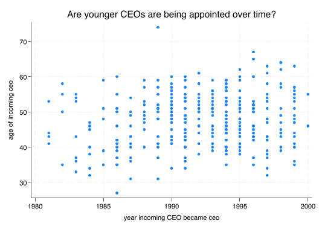

## Analysis

### Q4: Who appoints younger CEOs?

````markdown
```{stata}
scatter age assets, title(Do bigger firms appoint older CEOs?)
```
````

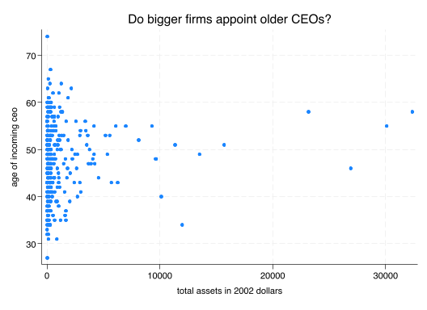

## Analysis

### Q4: Who appoints younger CEOs?

````markdown
```{stata}
gen lassets = log(assets)
label var lassets "log assets"
scatter age lassets, title(Do bigger firms appoint older CEOs?)
```
````

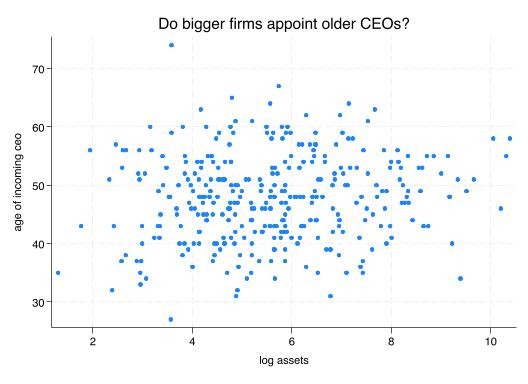

## Analysis

### Q5: Advantages and disadvantages of measurements

Discuss.

## Analysis

### Q6: *t*-test of the difference in return means around CEO transition. Family vs. unrelated.

````markdown
```{stata}
* All
ttest return == 0
```
````

```
One-sample t test
------------------------------------------------------------------------------
Variable |     Obs        Mean    Std. err.   Std. dev.   [95% conf. interval]
---------+--------------------------------------------------------------------
  return |     335     .009978    .0043588    .0797787    .0014039    .0185521
------------------------------------------------------------------------------
    mean = mean(return)                                           t =   2.2892
H0: mean = 0                                     Degrees of freedom =      334

    Ha: mean < 0                 Ha: mean != 0                 Ha: mean > 0
 Pr(T < t) = 0.9887         Pr(|T| > |t|) = 0.0227          Pr(T > t) = 0.0113
```

## Analysis

### Q6: *t*-test of the difference in return means around CEO transition. Family vs. unrelated.

````markdown
```{stata}
* Family transitions
ttest return == 0 if family == 1
```
````

```
One-sample t test
------------------------------------------------------------------------------
Variable |     Obs        Mean    Std. err.   Std. dev.   [95% conf. interval]
---------+--------------------------------------------------------------------
  return |     122   -.0017514    .0070519    .0778908   -.0157125    .0122097
------------------------------------------------------------------------------
    mean = mean(return)                                           t =  -0.2484
H0: mean = 0                                     Degrees of freedom =      121

    Ha: mean < 0                 Ha: mean != 0                 Ha: mean > 0
 Pr(T < t) = 0.4021         Pr(|T| > |t|) = 0.8043          Pr(T > t) = 0.5979
```

## Analysis

### Q6: *t*-test of the difference in return means around CEO transition. Family vs. unrelated.

````markdown
```{stata}
* Unrelated transitions
ttest return == 0 if family == 0
```
````

```
One-sample t test
------------------------------------------------------------------------------
Variable |     Obs        Mean    Std. err.   Std. dev.   [95% conf. interval]
---------+--------------------------------------------------------------------
  return |     213    .0166963    .0054986    .0802498    .0058573    .0275353
------------------------------------------------------------------------------
    mean = mean(return)                                           t =   3.0364
H0: mean = 0                                     Degrees of freedom =      212

    Ha: mean < 0                 Ha: mean != 0                 Ha: mean > 0
 Pr(T < t) = 0.9987         Pr(|T| > |t|) = 0.0027          Pr(T > t) = 0.0013
```

## Analysis

### Q6: *t*-test of the difference in return means around CEO transition. Family vs. unrelated.

````markdown
```{stata}
* Are the means equal?
ttest return, by(family) unequal
```
````

```
Two-sample t test with unequal variances
------------------------------------------------------------------------------
   Group |     Obs        Mean    Std. err.   Std. dev.   [95% conf. interval]
---------+--------------------------------------------------------------------
       0 |     213    .0166963    .0054986    .0802498    .0058573    .0275353
       1 |     122   -.0017514    .0070519    .0778908   -.0157125    .0122097
---------+--------------------------------------------------------------------
Combined |     335     .009978    .0043588    .0797787    .0014039    .0185521
---------+--------------------------------------------------------------------
    diff |            .0184477    .0089423                .0008387    .0360568
------------------------------------------------------------------------------
    diff = mean(0) - mean(1)                                      t =   2.0630
H0: diff = 0                     Satterthwaite's degrees of freedom =  258.354

    Ha: diff < 0                 Ha: diff != 0                 Ha: diff > 0
 Pr(T < t) = 0.9799         Pr(|T| > |t|) = 0.0401          Pr(T > t) = 0.0201
```

## Analysis

### Q7: Does the CEO’s pedigree matter?

````markdown
```{stata}
* Are the means equal?
ttest return, by(least_selective) unequal
```
````

```
Two-sample t test with unequal variances
------------------------------------------------------------------------------
   Group |     Obs        Mean    Std. err.   Std. dev.   [95% conf. interval]
---------+--------------------------------------------------------------------
       0 |     141    .0066376    .0075234    .0893359   -.0082367    .0215118
       1 |     194    .0124059    .0051828    .0721881    .0021837    .0226281
---------+--------------------------------------------------------------------
Combined |     335     .009978    .0043588    .0797787    .0014039    .0185521
---------+--------------------------------------------------------------------
    diff |           -.0057683    .0091358               -.0237574    .0122208
------------------------------------------------------------------------------
    diff = mean(0) - mean(1)                                      t =  -0.6314
H0: diff = 0                     Satterthwaite's degrees of freedom =  261.662

    Ha: diff < 0                 Ha: diff != 0                 Ha: diff > 0
 Pr(T < t) = 0.2642         Pr(|T| > |t|) = 0.5283          Pr(T > t) = 0.7358
```

## Analysis

### Q8: Does the CEO’s pedigree matter and family transitions matter?

````markdown
```{stata}
* To test whether the mean of return is different for selective transitions than for non-selective transitions for the group of family transitions
ttest return if family == 1, by(least_selective) unequal
```
````

```
Two-sample t test with unequal variances
------------------------------------------------------------------------------
   Group |     Obs        Mean    Std. err.   Std. dev.   [95% conf. interval]
---------+--------------------------------------------------------------------
       0 |      68   -.0026879    .0113521     .093612   -.0253469     .019971
       1 |      54   -.0005722    .0071627    .0526351   -.0149388    .0137945
---------+--------------------------------------------------------------------
Combined |     122   -.0017514    .0070519    .0778908   -.0157125    .0122097
---------+--------------------------------------------------------------------
    diff |           -.0021158    .0134229               -.0287193    .0244878
------------------------------------------------------------------------------
    diff = mean(0) - mean(1)                                      t =  -0.1576
H0: diff = 0                     Satterthwaite's degrees of freedom =  109.106

    Ha: diff < 0                 Ha: diff != 0                 Ha: diff > 0
 Pr(T < t) = 0.4375         Pr(|T| > |t|) = 0.8750          Pr(T > t) = 0.5625
```

## Analysis

### Q8: Does the CEO’s pedigree matter and family transitions matter?

````markdown
```{stata}
* To test whether the mean of return is different for selective transitions than for non-selective transitions for the group of unrelated transitions
ttest return if family == 0, by(least_selective) unequal
```
````

```
Two-sample t test with unequal variances
------------------------------------------------------------------------------
   Group |     Obs        Mean    Std. err.   Std. dev.   [95% conf. interval]
---------+--------------------------------------------------------------------
       0 |      73    .0153243    .0099348    .0848831   -.0044803     .035129
       1 |     140    .0174117    .0065947    .0780292    .0043728    .0304505
---------+--------------------------------------------------------------------
Combined |     213    .0166963    .0054986    .0802498    .0058573    .0275353
---------+--------------------------------------------------------------------
    diff |           -.0020873    .0119244               -.0256688    .0214941
------------------------------------------------------------------------------
    diff = mean(0) - mean(1)                                      t =  -0.1750
H0: diff = 0                     Satterthwaite's degrees of freedom =  135.774

    Ha: diff < 0                 Ha: diff != 0                 Ha: diff > 0
 Pr(T < t) = 0.4307         Pr(|T| > |t|) = 0.8613          Pr(T > t) = 0.5693
```

## Analysis

### Q9: Does the CEO’s pedigree matter and family transitions matter? 2.0

````markdown
```{stata}
* To test whether the mean of return is different for family transitions than for unrelated transitions for the group of selective transitions
ttest return if least_selective == 0, by(family) unequal
```
````

```
Two-sample t test with unequal variances
------------------------------------------------------------------------------
   Group |     Obs        Mean    Std. err.   Std. dev.   [95% conf. interval]
---------+--------------------------------------------------------------------
       0 |      73    .0153243    .0099348    .0848831   -.0044803     .035129
       1 |      68   -.0026879    .0113521     .093612   -.0253469     .019971
---------+--------------------------------------------------------------------
Combined |     141    .0066376    .0075234    .0893359   -.0082367    .0215118
---------+--------------------------------------------------------------------
    diff |            .0180123    .0150855               -.0118218    .0478464
------------------------------------------------------------------------------
    diff = mean(0) - mean(1)                                      t =   1.1940
H0: diff = 0                     Satterthwaite's degrees of freedom =  135.156

    Ha: diff < 0                 Ha: diff != 0                 Ha: diff > 0
 Pr(T < t) = 0.8827         Pr(|T| > |t|) = 0.2346          Pr(T > t) = 0.1173
```

## Analysis

### Q9: Does the CEO’s pedigree matter and family transitions matter? 2.0

````markdown
```{stata}
* To test whether the mean of return is different for family transitions than for unrelated transitions for the group of non-selective transitions
ttest return if least_selective == 1, by(family) unequal
```
````

```
Two-sample t test with unequal variances
------------------------------------------------------------------------------
   Group |     Obs        Mean    Std. err.   Std. dev.   [95% conf. interval]
---------+--------------------------------------------------------------------
       0 |     140    .0174117    .0065947    .0780292    .0043728    .0304505
       1 |      54   -.0005722    .0071627    .0526351   -.0149388    .0137945
---------+--------------------------------------------------------------------
Combined |     194    .0124059    .0051828    .0721881    .0021837    .0226281
---------+--------------------------------------------------------------------
    diff |            .0179838    .0097362               -.0012629    .0372305
------------------------------------------------------------------------------
    diff = mean(0) - mean(1)                                      t =   1.8471
H0: diff = 0                     Satterthwaite's degrees of freedom =  142.025

    Ha: diff < 0                 Ha: diff != 0                 Ha: diff > 0
 Pr(T < t) = 0.9666         Pr(|T| > |t|) = 0.0668          Pr(T > t) = 0.0334
```

## Analysis

### Q10: Should we use the ItA ratio?

What if the transition led to an increase in the ItA ratiorather than the other way around?

## Analysis

### Q11: Does the CEO’s pedigree matter and family transitions matter? 3.0

Repeat past questions with $\Delta \text{Profits}_{it}$.

````markdown
```{stata}
ttest change_profits, by(family) unequal
ttest change_profits, by(least_selective) unequal
reg change_profits family
reg change_profits least_selective

ttest change_profits if family == 1, by(least_selective) unequal
ttest change_profits if family == 0, by(least_selective) unequal
ttest change_profits if least_selective == 1, by(family) unequal
ttest change_profits if least_selective == 0, by(family) unequal
```
````

```
Two-sample t test with unequal variances
------------------------------------------------------------------------------
   Group |     Obs        Mean    Std. err.   Std. dev.   [95% conf. interval]
---------+--------------------------------------------------------------------
       0 |     213    .0020657    .0049574    .0723503   -.0077063    .0118377
       1 |     122    -.018801    .0059421    .0656329    -.030565    -.007037
---------+--------------------------------------------------------------------
Combined |     335   -.0055335    .0038572    .0705991    -.013121     .002054
---------+--------------------------------------------------------------------
    diff |            .0208667    .0077385                .0056319    .0361015
------------------------------------------------------------------------------
    diff = mean(0) - mean(1)                                      t =   2.6965
H0: diff = 0                     Satterthwaite's degrees of freedom =  272.663

    Ha: diff < 0                 Ha: diff != 0                 Ha: diff > 0
 Pr(T < t) = 0.9963         Pr(|T| > |t|) = 0.0074          Pr(T > t) = 0.0037

Two-sample t test with unequal variances
------------------------------------------------------------------------------
   Group |     Obs        Mean    Std. err.   Std. dev.   [95% conf. interval]
---------+--------------------------------------------------------------------
       0 |     141   -.0024147    .0054998    .0653063   -.0132881    .0084587
       1 |     194   -.0078002     .005334    .0742938   -.0183206    .0027201
---------+--------------------------------------------------------------------
Combined |     335   -.0055335    .0038572    .0705991    -.013121     .002054
---------+--------------------------------------------------------------------
    diff |            .0053855    .0076615               -.0096876    .0204587
------------------------------------------------------------------------------
    diff = mean(0) - mean(1)                                      t =   0.7029
H0: diff = 0                     Satterthwaite's degrees of freedom =  321.136

    Ha: diff < 0                 Ha: diff != 0                 Ha: diff > 0
 Pr(T < t) = 0.7587         Pr(|T| > |t|) = 0.4826          Pr(T > t) = 0.2413

      Source |       SS           df       MS      Number of obs   =       335
-------------+----------------------------------   F(1, 333)       =      6.90
       Model |  .033775442         1  .033775442   Prob > F        =    0.0090
    Residual |  1.63095823       333  .004897772   R-squared       =    0.0203
-------------+----------------------------------   Adj R-squared   =    0.0173
       Total |  1.66473367       334  .004984233   Root MSE        =    .06998
```

[output cut: 74 more lines]

```
------------------------------------------------------------------------------
   Group |     Obs        Mean    Std. err.   Std. dev.   [95% conf. interval]
---------+--------------------------------------------------------------------
       0 |      73   -.0051352    .0084086     .071843   -.0218974     .011627
       1 |      68    .0005058    .0070172    .0578657   -.0135006    .0145123
---------+--------------------------------------------------------------------
Combined |     141   -.0024147    .0054998    .0653063   -.0132881    .0084587
---------+--------------------------------------------------------------------
    diff |           -.0056411     .010952                -.027299    .0160169
------------------------------------------------------------------------------
    diff = mean(0) - mean(1)                                      t =  -0.5151
H0: diff = 0                     Satterthwaite's degrees of freedom =  136.212

    Ha: diff < 0                 Ha: diff != 0                 Ha: diff > 0
 Pr(T < t) = 0.3037         Pr(|T| > |t|) = 0.6073          Pr(T > t) = 0.6963
```

## Analysis

### Q11: Does the CEO’s pedigree matter and family transitions matter? 3.0

Disentangle the effects.

````markdown
```{stata}
generate ls0f0 = (family == 0 & least_selective == 0)
generate ls0f1 = (family == 1 & least_selective == 0)
generate ls1f0 = (family == 0 & least_selective == 1)
generate ls1f1 = (family == 1 & least_selective == 1)

reg change_profits ls0f0 ls0f1 ls1f1

test ls0f0 = ls0f1
```
````

```
      Source |       SS           df       MS      Number of obs   =       335
-------------+----------------------------------   F(3, 331)       =      6.81
       Model |  .096800361         3  .032266787   Prob > F        =    0.0002
    Residual |  1.56793331       331  .004736959   R-squared       =    0.0581
-------------+----------------------------------   Adj R-squared   =    0.0496
       Total |  1.66473367       334  .004984233   Root MSE        =    .06883

------------------------------------------------------------------------------
change_pro~s | Coefficient  Std. err.      t    P>|t|     [95% conf. interval]
-------------+----------------------------------------------------------------
       ls0f0 |  -.0109557   .0099361    -1.10   0.271    -.0305015    .0085901
       ls0f1 |  -.0053146   .0101733    -0.52   0.602    -.0253272    .0146979
       ls1f1 |  -.0489337   .0110253    -4.44   0.000    -.0706222   -.0272453
       _cons |   .0058205   .0058168     1.00   0.318    -.0056221    .0172631
------------------------------------------------------------------------------

 ( 1)  ls0f0 - ls0f1 = 0

       F(  1,   331) =    0.24
            Prob > F =    0.6271
```

# Q12: Take a stance: Family or external?

## Summary

- Administrative.
- Presentation.
- Analysis.
- Descriptive statistics.
- *t*-tests.
- Interpretation.